# ISLR Chapter 7 Applied Exercises

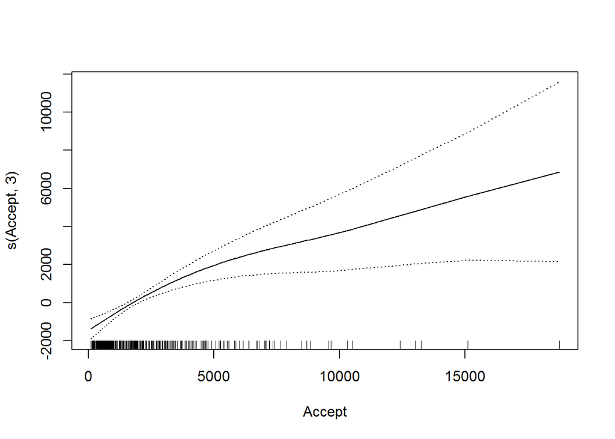

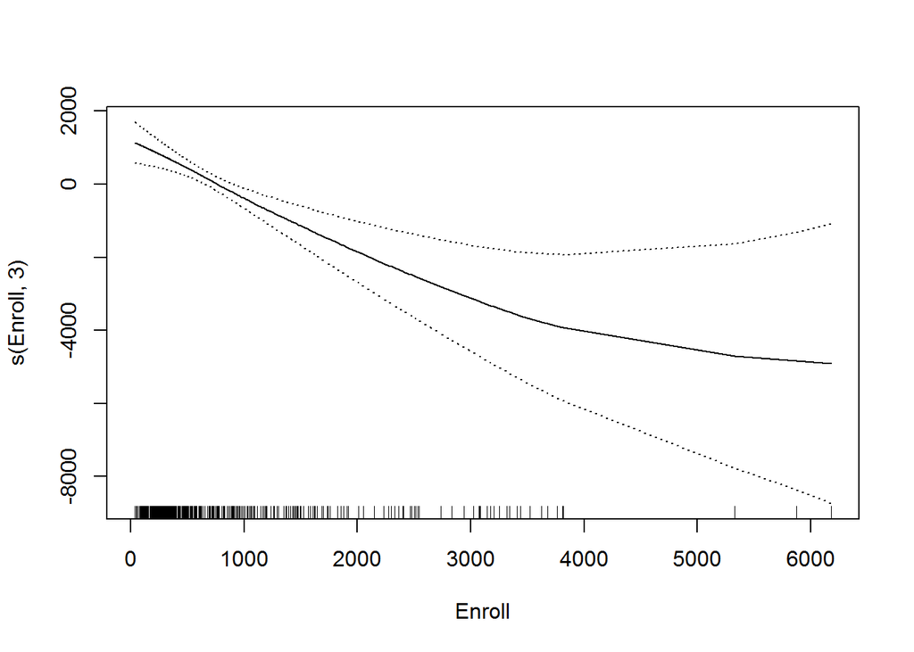

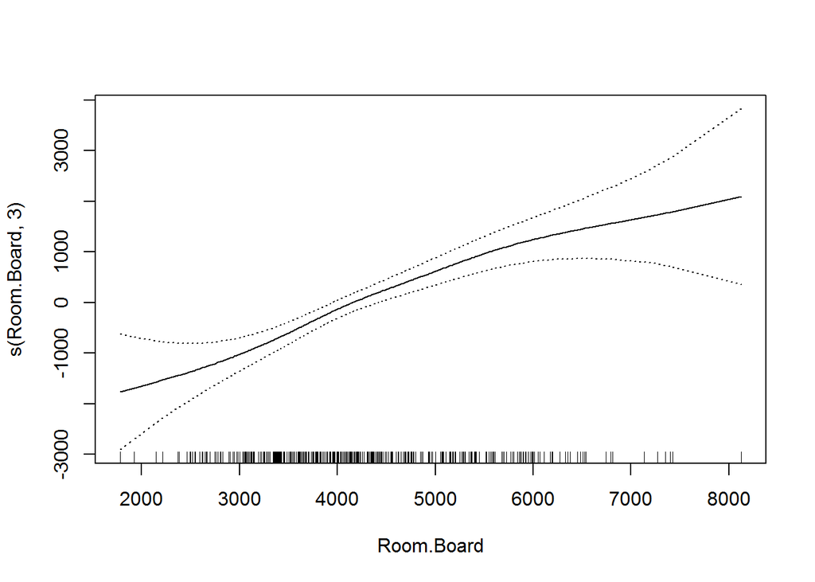

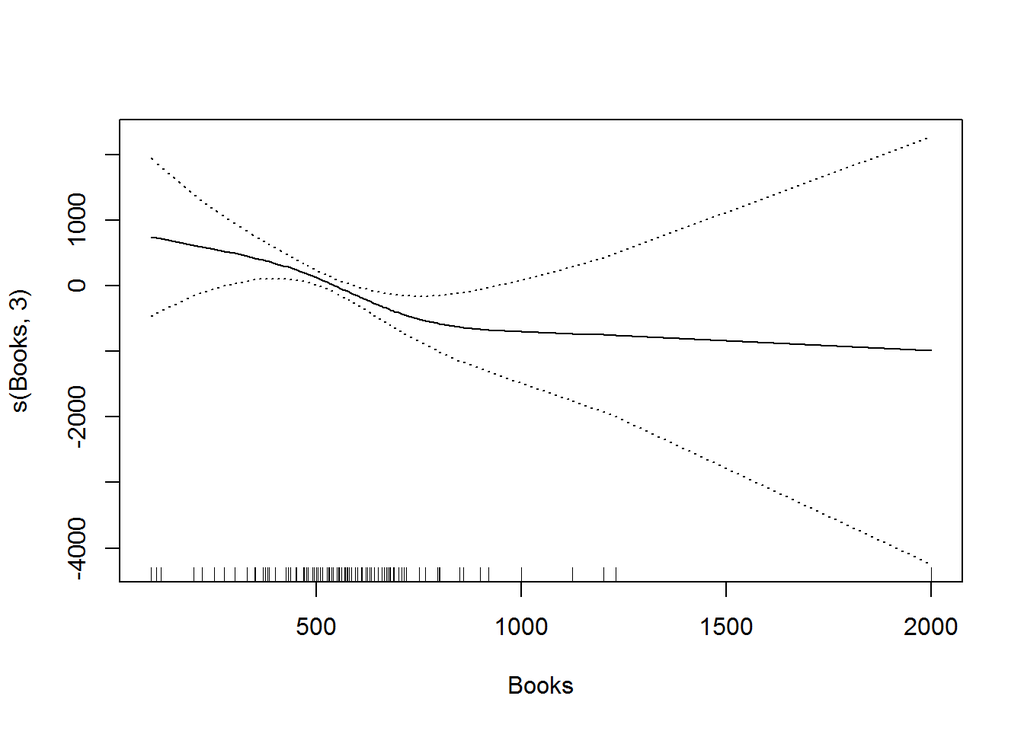

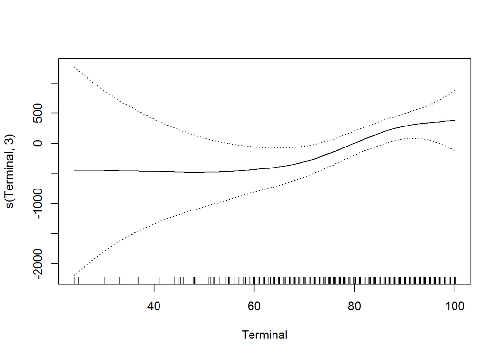

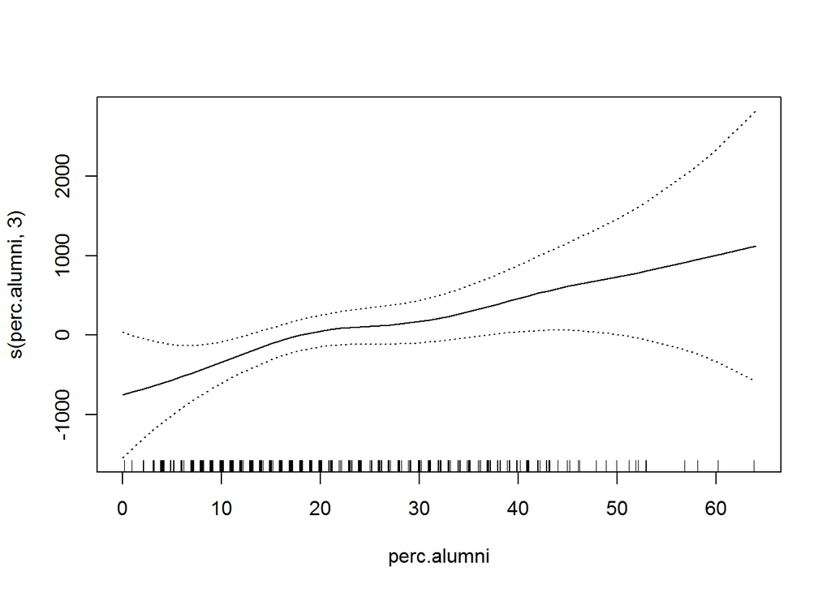

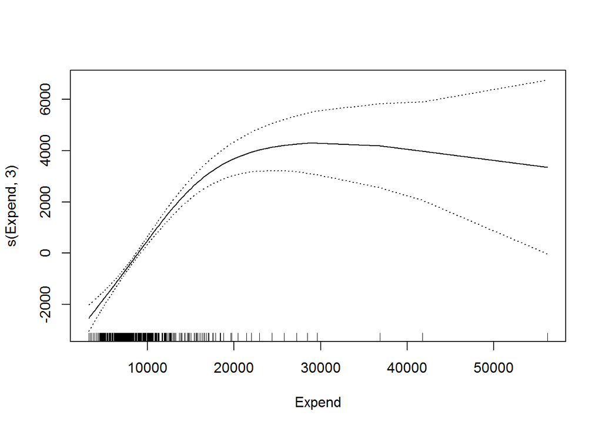

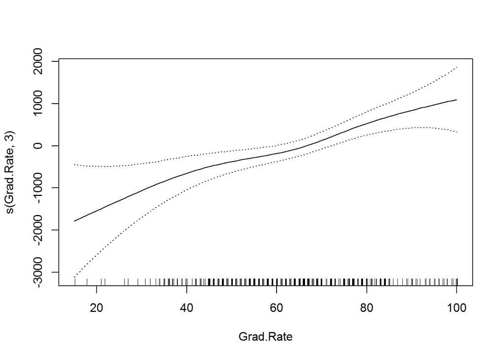

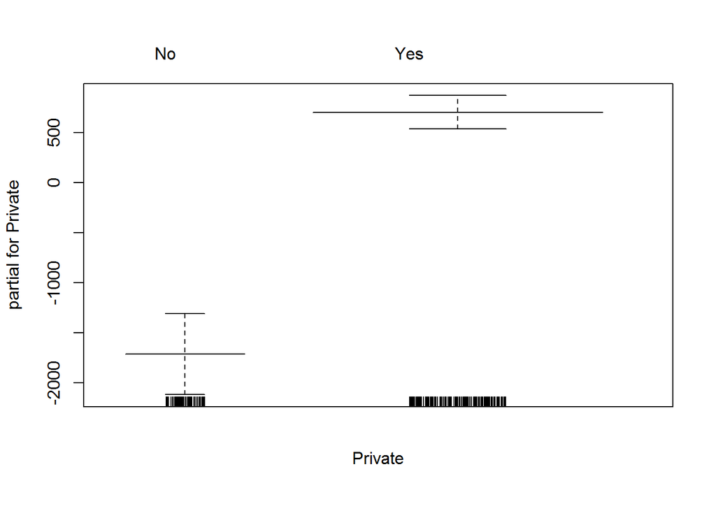

```r
plot.gam.df3 = plot(gam.fit.df3, se = T)
```

Next, we use the same scale for all variables to see which variables are more important.

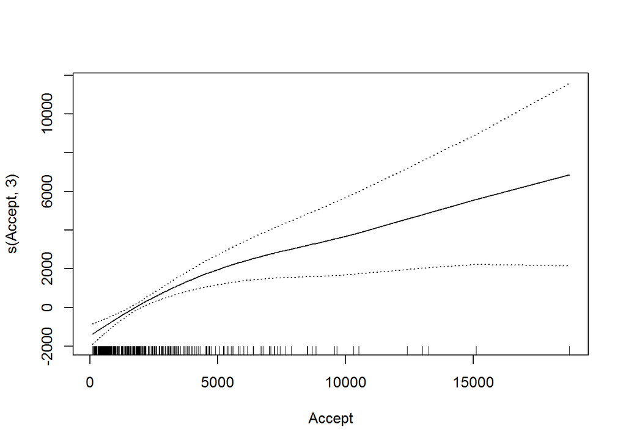

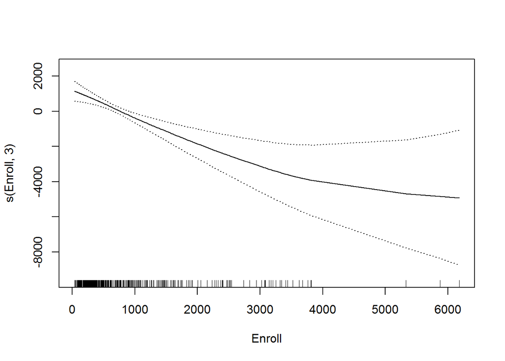

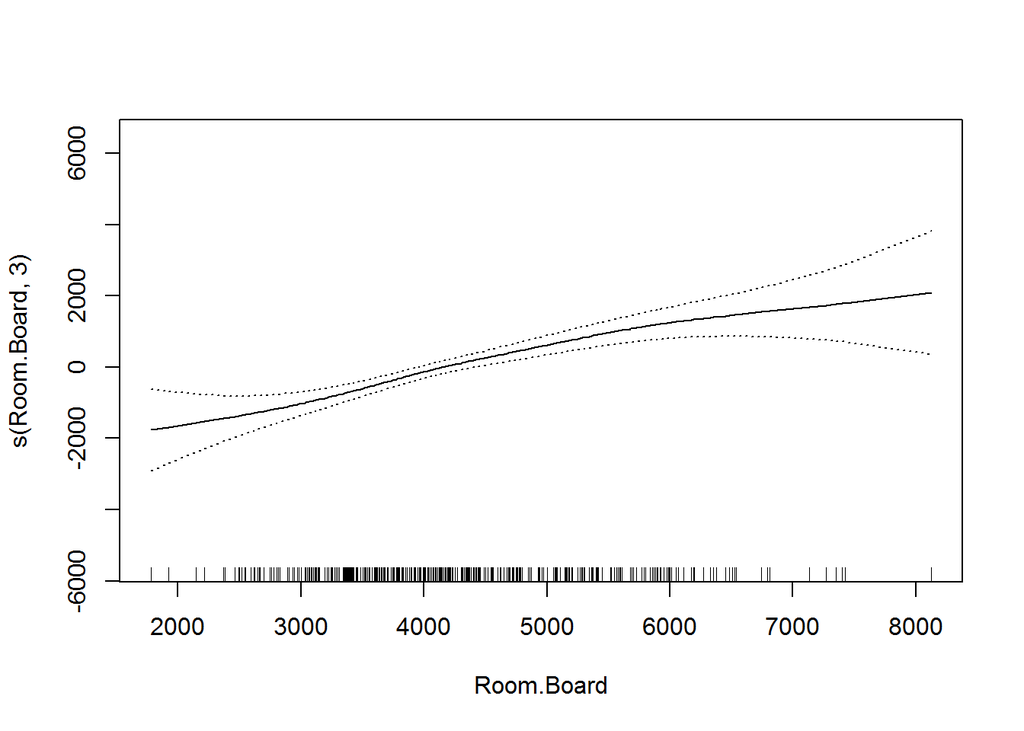

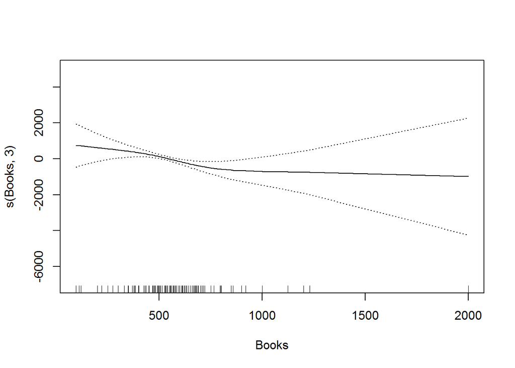

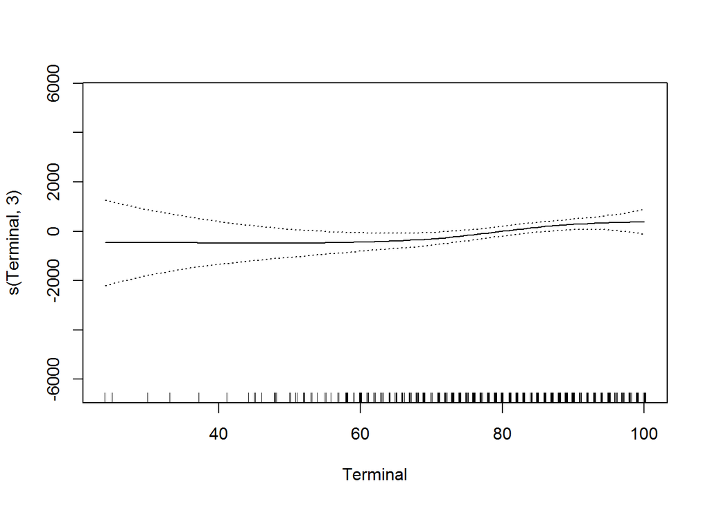

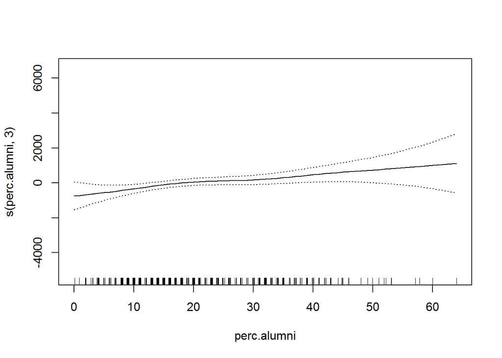

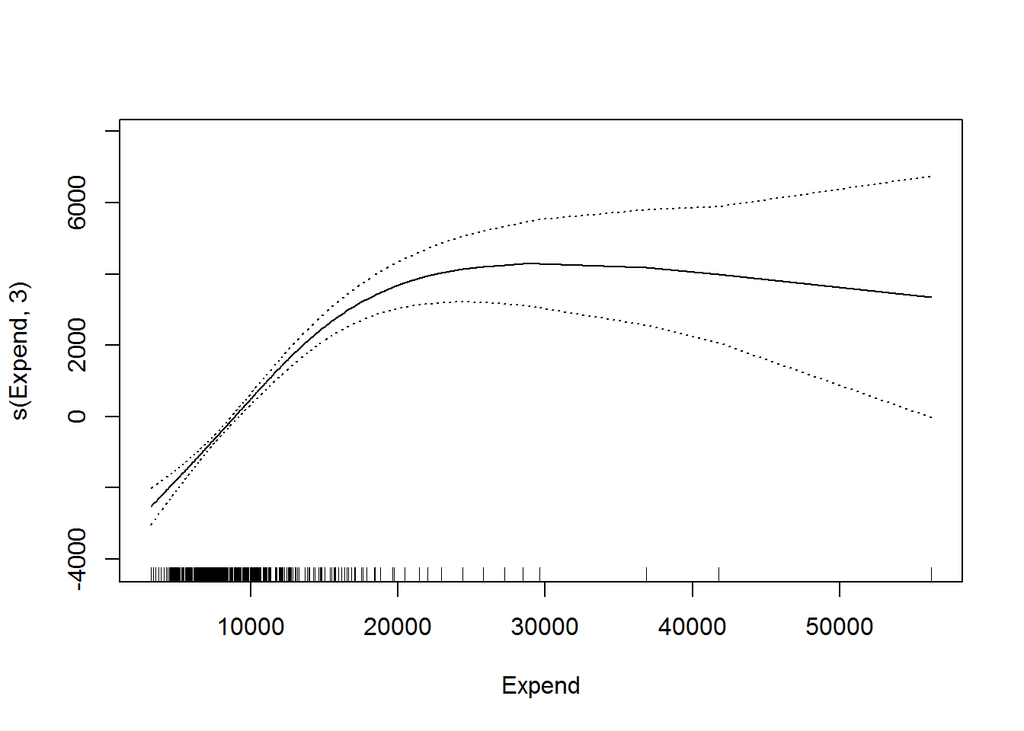

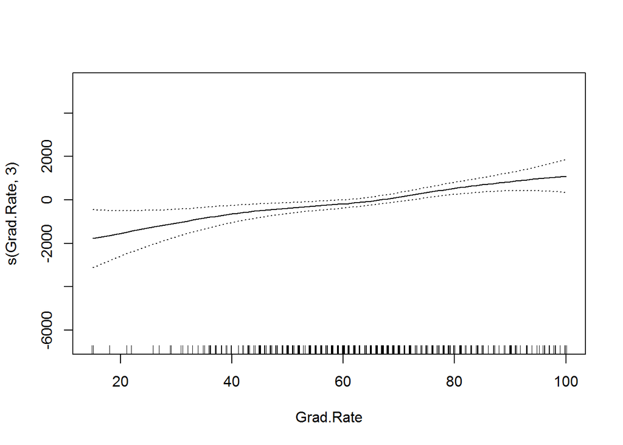

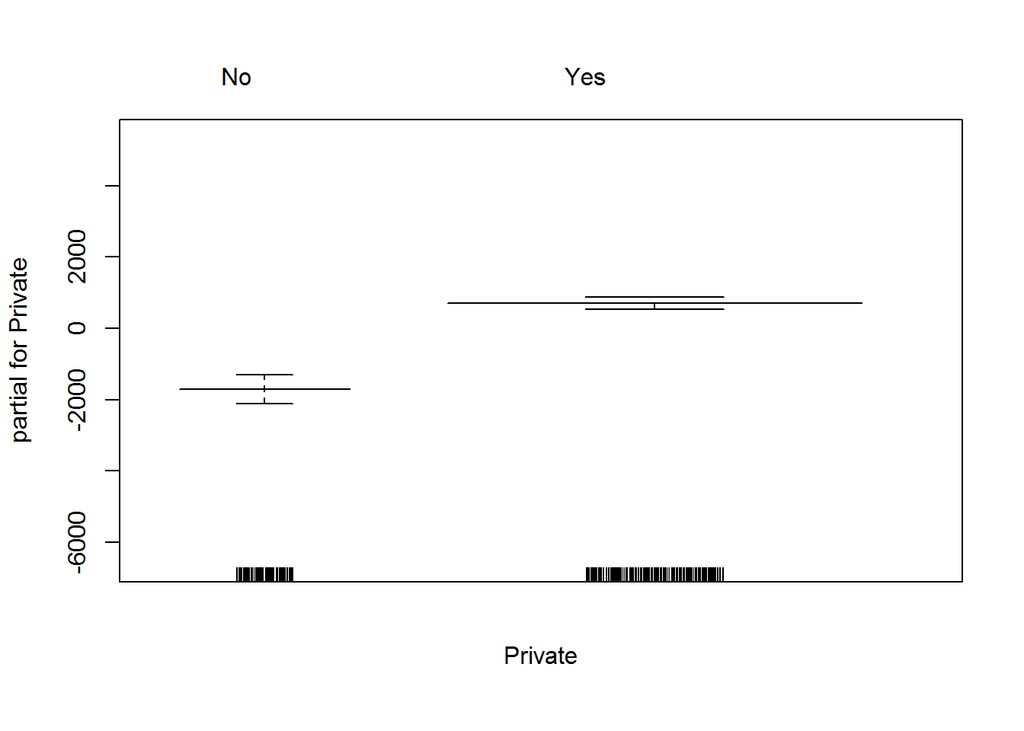

```r
plot(gam.fit.df3, se = T, scale = 12000)
```

Two important things from the plots:

- Possibility of outliers and leverage points, e.g. for `Accept` and `Enroll`
- Interaction and normalized variables
  - interaction of private and other variables: private schools tuitions are expected to be more sensitive to changes
  - rates of enrollment and acceptance
- Small linear effects of some variables.
- There are both demand and supply side effects influencing how the tuition is determined
  - Apps normalized by Enroll (to account for school size) could proxy demand,
  - Supply would be the current capacity, which would equal `Enroll` if admission committee knows the percentage of students who accept the admssion offer
  - The resulting endogeneity makes causal inference impossible

The model estimated above used three degrees of freedom for all variables. After looking at the resulting plots, we try two other combinations of degrees of freedom. Below, we lower the degrees for some variables:

```r
gam.fit.df321 = gam(Outstate ~ s(Accept, 3) + s(Enroll, 3) + s(Books, 3) + s(Expend, 3) +
                            s(Terminal, 2) + s(perc.alumni, 2) + s(Room.Board, 2) +
                            Grad.Rate + Private,
                 data = College, subset = train)
summary(gam.fit.df321)
```

```
##
## Call: gam(formula = Outstate ~ s(Accept, 3) + s(Enroll, 3) + s(Books,
##     3) + s(Expend, 3) + s(Terminal, 2) + s(perc.alumni, 2) +
##     s(Room.Board, 2) + Grad.Rate + Private, data = College, subset = train)
## Deviance Residuals:
##       Min        1Q    Median        3Q       Max
## -5754.752 -1048.003    -6.608  1126.070  8771.808
##
## (Dispersion Parameter for gaussian family taken to be 3263286)
##
##     Null Deviance: 6306847377 on 418 degrees of freedom
## Residual Deviance: 1298788183 on 398.0001 degrees of freedom
## AIC: 7495.791
##
## Number of Local Scoring Iterations: 2
##
## Anova for Parametric Effects
##                    Df     Sum Sq    Mean Sq  F value    Pr(>F)
## s(Accept, 3)        1    1306237    1306237   0.4003    0.5273
## s(Enroll, 3)        1 1012152254 1012152254 310.1635 < 2.2e-16 ***
## s(Books, 3)         1     489243     489243   0.1499    0.6988
## s(Expend, 3)        1 2171370769 2171370769 665.3939 < 2.2e-16 ***
## s(Terminal, 2)      1   64235946   64235946  19.6844 1.184e-05 ***
## s(perc.alumni, 2)   1  240055906  240055906  73.5626 < 2.2e-16 ***
## s(Room.Board, 2)    1  368196068  368196068 112.8298 < 2.2e-16 ***
## Grad.Rate           1  123155121  123155121  37.7396 1.962e-09 ***
## Private             1  223175957  223175957  68.3899 2.033e-15 ***
## Residuals         398 1298788183    3263286
## ---
## Signif. codes:  0 '***' 0.001 '**' 0.01 '*' 0.05 '.' 0.1 ' ' 1
##
## Anova for Nonparametric Effects
##                   Npar Df Npar F     Pr(F)
## (Intercept)
## s(Accept, 3)            2  5.930   0.00290 **
## s(Enroll, 3)            2  3.797   0.02326 *
## s(Books, 3)             2  1.786   0.16889
## s(Expend, 3)            2 35.243 8.105e-15 ***
## s(Terminal, 2)          1  1.240   0.26616
## s(perc.alumni, 2)       1  0.779   0.37791
## s(Room.Board, 2)        1  1.653   0.19929
## Grad.Rate
## Private
## ---
## Signif. codes:  0 '***' 0.001 '**' 0.01 '*' 0.05 '.' 0.1 ' ' 1
```

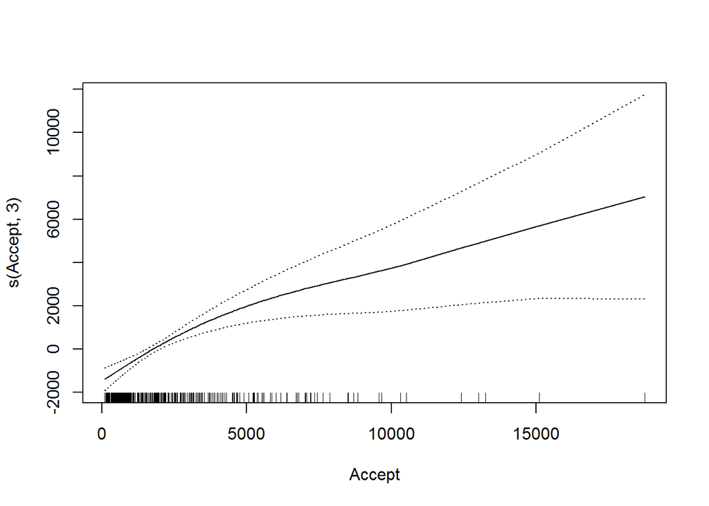

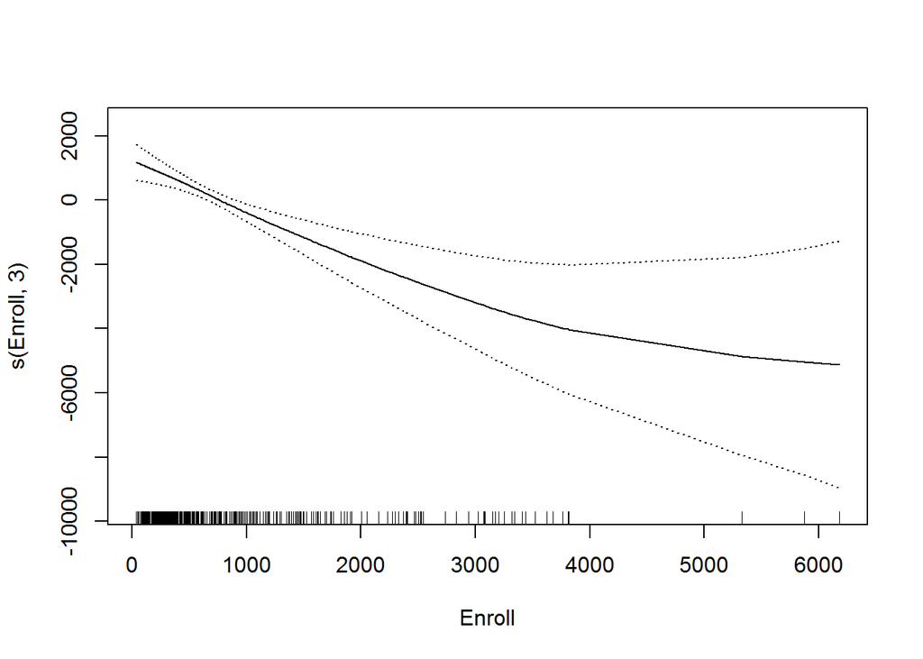

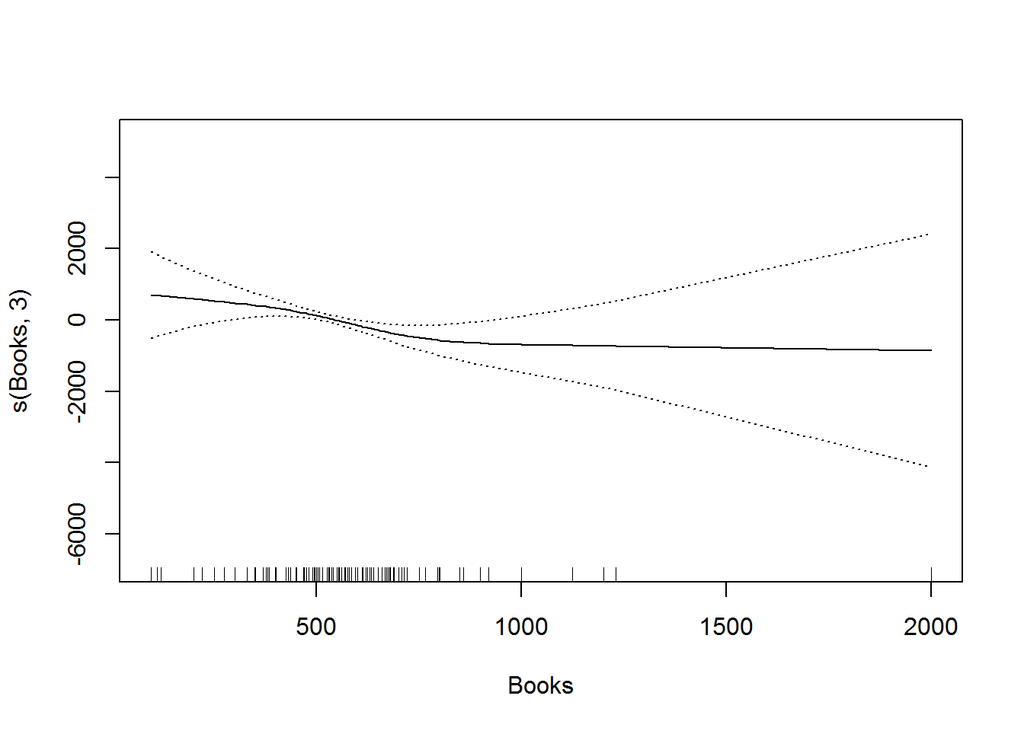

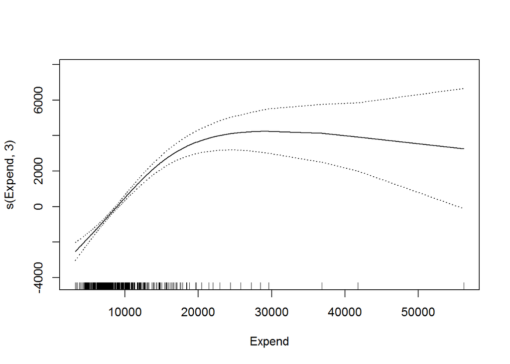

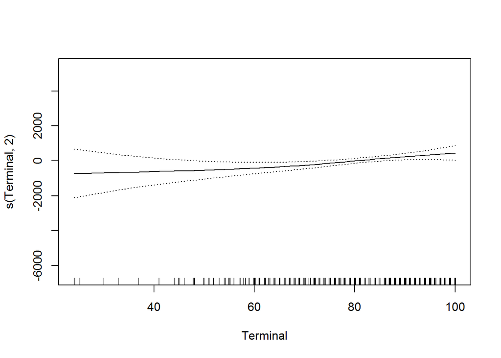

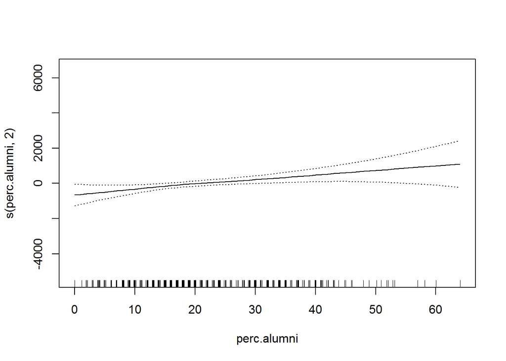

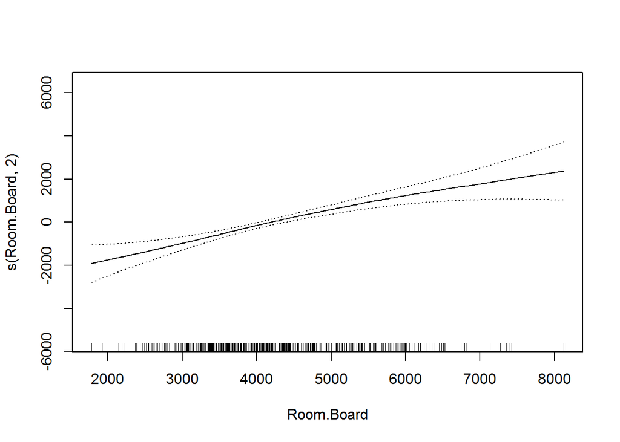

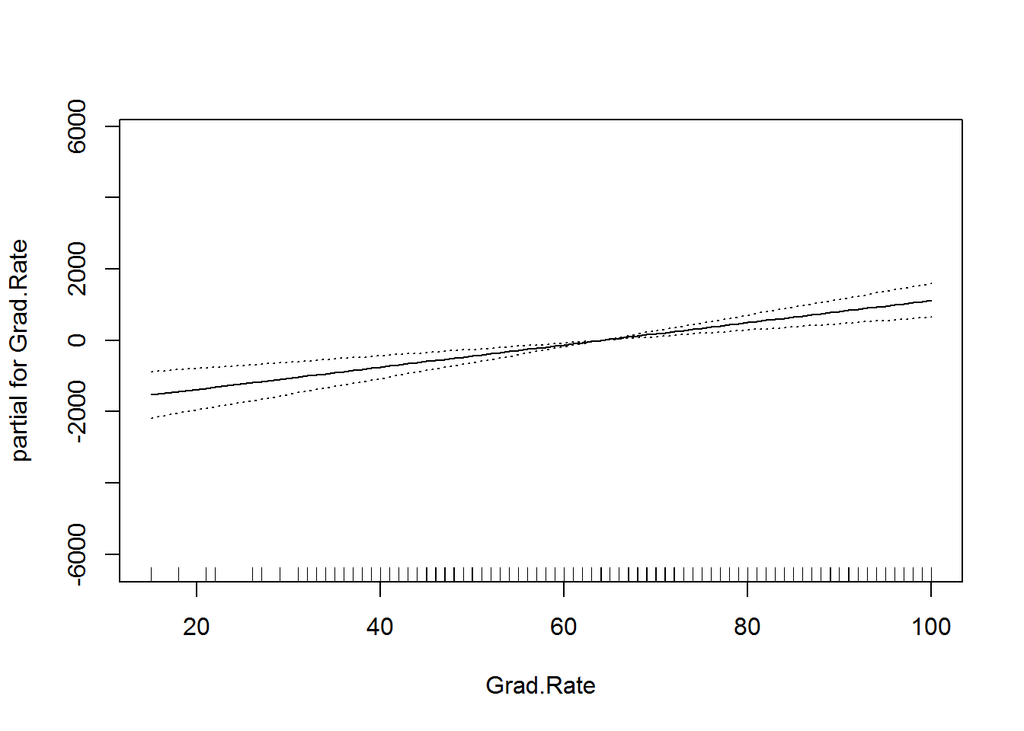

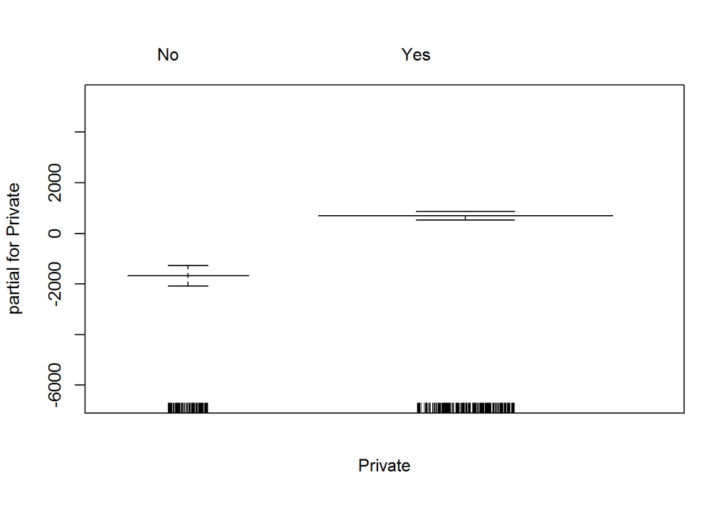

```r
plot(gam.fit.df321, se = T, scale = 12000)
```

We further lower degrees, by making all quadratic terms linear now. We also introduce some interactions. It makes sense intuitively that the pricing behavior of private schools be more or less sensitive to different predictors, for example because profit-making is expected to play less of a role in their decision making. Hence, we introduced interactions of being a private school with the linear terms. Then we picked those that seemed more promising in the linear regression to be included in GAM. Since this is done on the training set, we do not worry about overfitting. We will finally be able to evaluate whether the model works on the test data.

```r
gam.fit.df31 = gam(Outstate ~ s(Accept, 3) + s(Enroll, 3) + s(Expend, 3) +
                            Books*Private + Terminal + perc.alumni + Room.Board*Private +
                            Private + Private + Top10perc,
                 data = College, subset = train)
summary(gam.fit.df31)
```

```
##
## Call: gam(formula = Outstate ~ s(Accept, 3) + s(Enroll, 3) + s(Expend,
##     3) + Books * Private + Terminal + perc.alumni + Room.Board *
##     Private + Private + Private + Top10perc, data = College,
##     subset = train)
## Deviance Residuals:
##      Min       1Q   Median       3Q      Max
## -4900.85 -1165.99    58.61  1155.77  8676.32
##
## (Dispersion Parameter for gaussian family taken to be 3340420)
##
##     Null Deviance: 6306847377 on 418 degrees of freedom
## Residual Deviance: 1339508072 on 400.9999 degrees of freedom
## AIC: 7502.726
##
## Number of Local Scoring Iterations: 2
##
## Anova for Parametric Effects
##                     Df     Sum Sq    Mean Sq  F value    Pr(>F)
## s(Accept, 3)         1    1498199    1498199   0.4485  0.503431
## s(Enroll, 3)         1 1063485880 1063485880 318.3689 < 2.2e-16 ***
## s(Expend, 3)         1 2137789077 2137789077 639.9762 < 2.2e-16 ***
## Books                1    5740427    5740427   1.7185  0.190640
## Private              1  560538061  560538061 167.8047 < 2.2e-16 ***
## Terminal             1  145161297  145161297  43.4560 1.369e-10 ***
## perc.alumni          1   66904527   66904527  20.0288 9.953e-06 ***
## Room.Board           1  182291512  182291512  54.5714 8.774e-13 ***
## Top10perc            1   13006086   13006086   3.8935  0.049158 *
## Books:Private        1   15946280   15946280   4.7737  0.029475 *
## Private:Room.Board   1   30931939   30931939   9.2599  0.002496 **
## Residuals          401 1339508072    3340420
## ---
## Signif. codes:  0 '***' 0.001 '**' 0.01 '*' 0.05 '.' 0.1 ' ' 1
##
## Anova for Nonparametric Effects
##                    Npar Df  Npar F     Pr(F)
## (Intercept)
## s(Accept, 3)             2  9.0352 0.0001452 ***
## s(Enroll, 3)             2  6.8055 0.0012401 **
## s(Expend, 3)             2 29.6548 9.743e-13 ***
## Books
## Private
## Terminal
## perc.alumni
## Room.Board
## Top10perc
## Books:Private
## Private:Room.Board
## ---
## Signif. codes:  0 '***' 0.001 '**' 0.01 '*' 0.05 '.' 0.1 ' ' 1
```

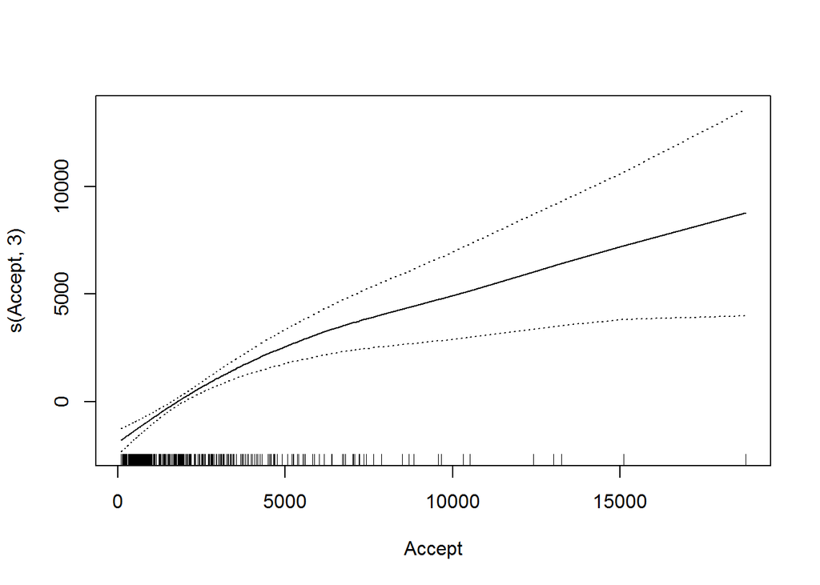

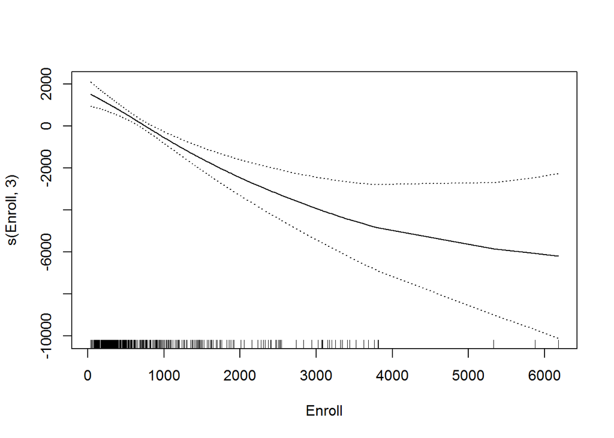

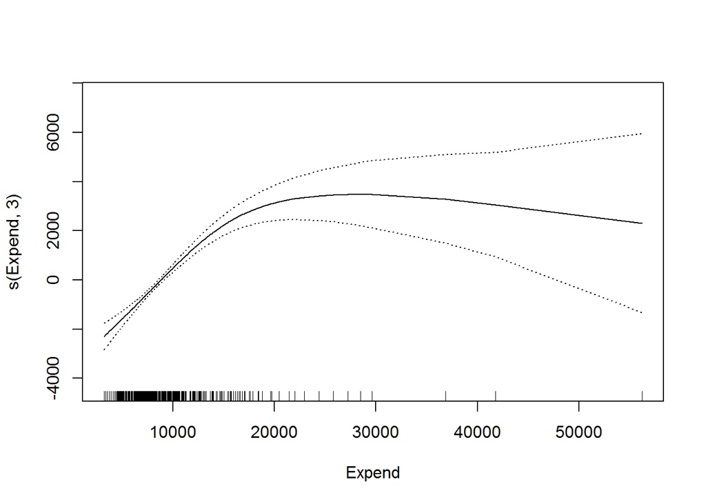

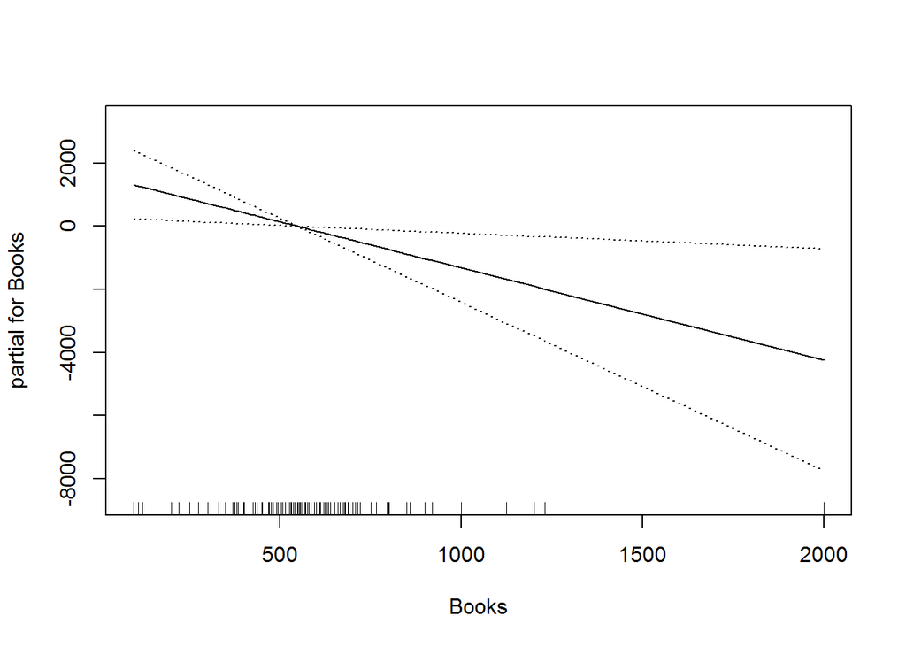

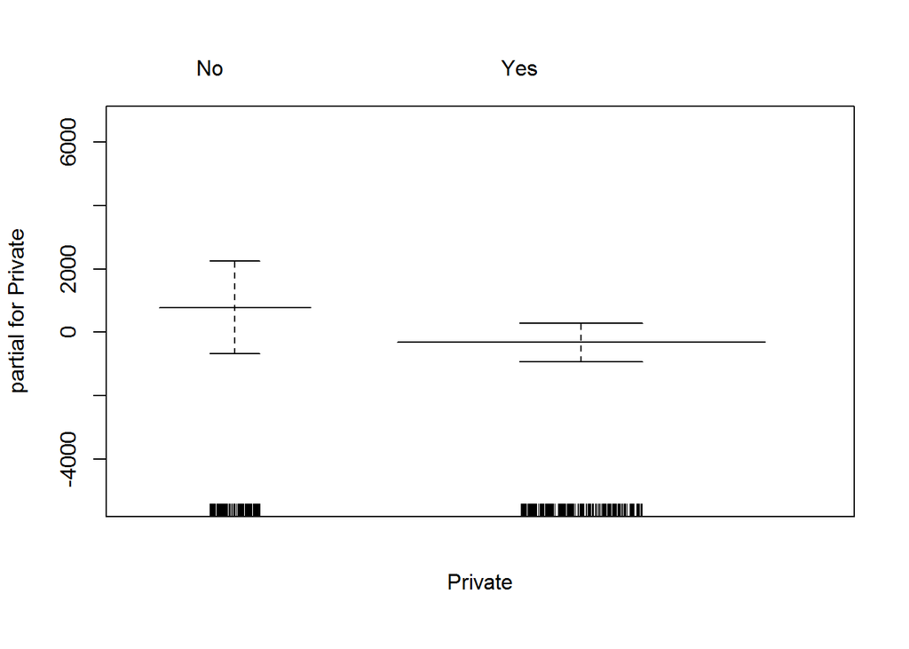

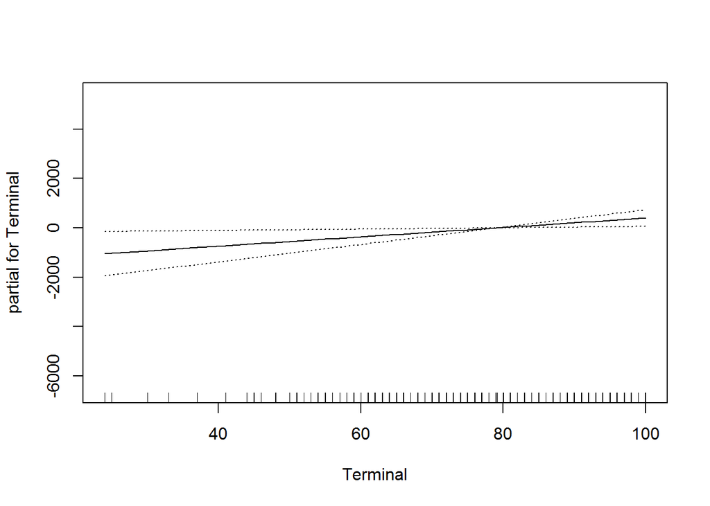

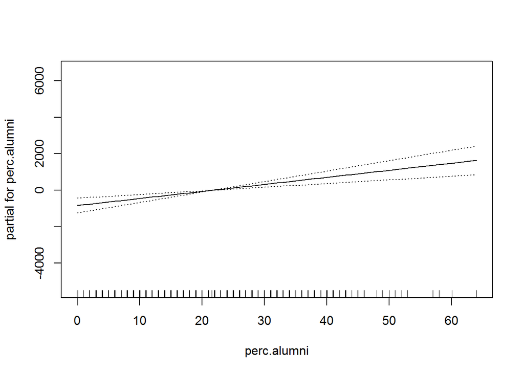

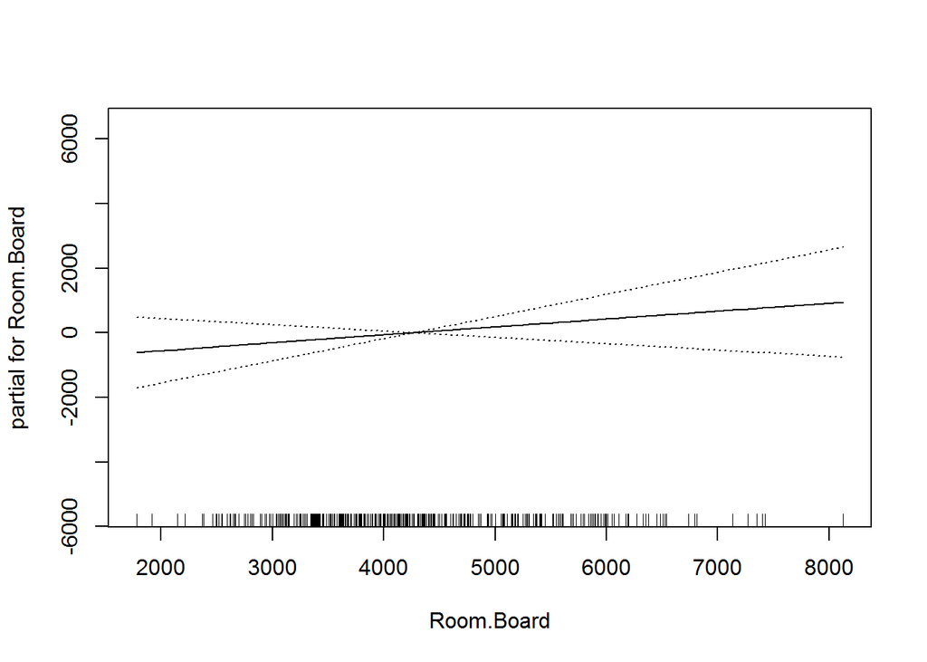

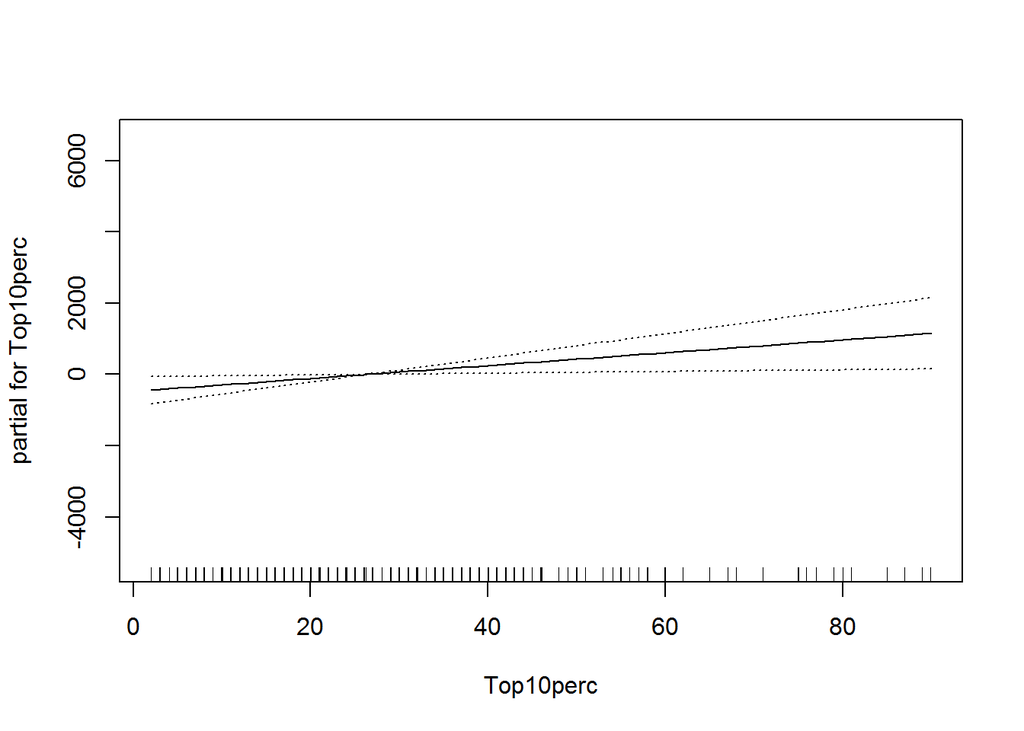

```r
plot(gam.fit.df31, se = T, scale = 12000)
```

## Part 10.c)

We evaluate the models we estimated in the previous part.

```r
# Setup
test.mse = rep(NA, length = 3)
gam.models = list(gam.fit.df3, gam.fit.df321, gam.fit.df31)
# predict for the test set
for (i in 1:length(gam.models)) {
  preds = predict(gam.models[[i]], newdata = College[test, ])
  test.mse[i] = mean((College$Outstate[test] - preds)^2)
}
names(test.mse) = c("df=3", "df=3,2,1", "Interact")
sqrt(test.mse)
```

```
##     df=3 df=3,2,1 Interact
## 1906.054 1905.415 1881.946
```

The last GAM model that we used (the one with interactions) has the least error, as indicated by square roots of MSE above.

```r
mean(College$Outstate[test])
```

```
## [1] 10834.26
```

The model is doing a good job when comparing the average value of response to the squre root of MSE (which tends to be a bit higher than mean absolute value of differene), implying that the model has reasonable predictive power.  
In the test set, the actual tuition deviates from the predicted tuition by approximately $1880, on average. The mean value of tuition across the schools in the test set implies that the estimate for the precentage error is less than 20%. This is pretty good, when we note that it also includes the irreducible error.

## Part 10.d)

There is clear evidence for non-linearity in Acceptance, Enrollment and Expenditure and evidence of interaction between `Private` and some of the variables.  
Future work could consider the interaction of `Private` with the non-linear variables, and how it affects the test MSE. The drawback of such interaction, however, is that we could not see ANOVA results for interactions.

# Exercise 11

Backfitting:

```r
# SEtup
beta1 = -1
beta2 = 3
beta0 = 0
x1 = rnorm(100)
x2 = rnorm(100)
eps = rnorm(100)
y = beta0 + beta1*x1 + beta2*x2 + eps
# initialize
beta1hat = 3
# find partial residual for x2
r = y - beta1hat*x1
beta2hat = coef(lm(r ~ x2))[2]
```

Below, we run the codes for parts e), f) and g) of Question 11.

```r
# initialize
n.iter = 1000
beta1hat = -100
param.values = matrix(NA, nrow = n.iter, ncol = 4,
                      dimnames = list(paste(1:n.iter),
                                      c("beta0_1" , "beta1hat", "beta0_2", "beta2hat")))
for (i in 1:n.iter) {
  # First regression: partial residual for x2
  r2 = y - beta1hat*x1
  coef.1 = coef(lm(r2 ~ x2))
  beta2hat = coef.1[2]
  param.values[i, 1:2] = coef.1
  # Second: partial for x1
  r1 = y - beta2hat*x2
  coef.2 = coef(lm(r1 ~ x1))
  beta1hat = coef.2[2]
  param.values[i, 3:4] = coef.2
}
c(beta1hat, beta2hat)
```

```
##         x1         x2
## -0.9533402  3.0948298
```

```r
c(beta1, beta2)
```

```
## [1] -1  3
```

```r
matplot(param.values[1:20, ], type = "l", lty = 1)
coef.mult = coef(lm(y ~ x1 + x2))
coef.mult
```

```
## (Intercept)          x1          x2
##  -0.0887722  -0.9533402   3.0948298
```

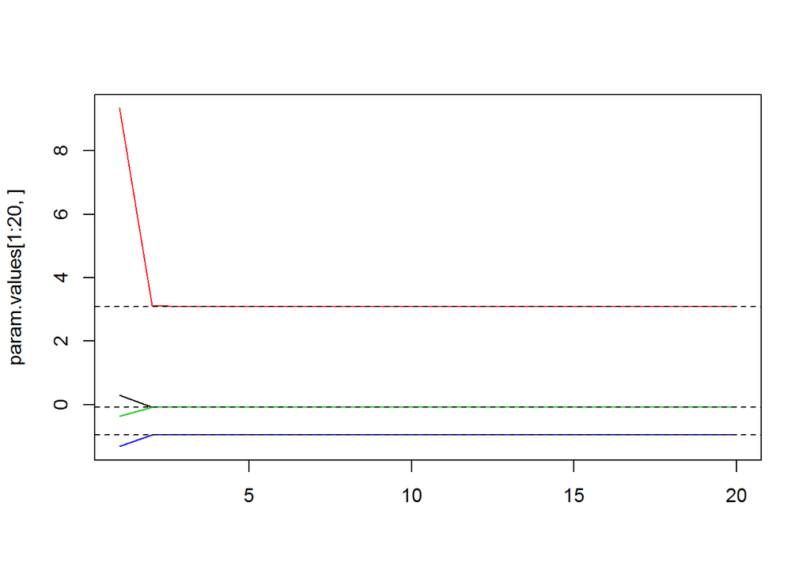

```r
abline(h = coef.mult, lty = 2)
```

The dotted lines depict the multiple regression results. Convergence happens very fast and lines are indistinguishable from the backfitting lines at the second iteration.

# Exercise 12

Number of required backfitting iterations depends on n and p. If n=p, multiple regression could not fit and backfitting would not lead to findng population parameters (for example, for n=p = 9, 800 and 8000 iterations both result in an error equal to 0.707). When n>p, backfitting finds the population parameters, but the more the dimensions are, i.e. where there is more overfitting, the more the iterations that are needed to achieve convergence (for example for p = 10 and n = 500, the error in 9 iterations is 2.606071e-11, while if we only change n to 50, the error in 9 iterations would be 0.002587096). *The code for this paragraph’s numbers is not available. A variant on the code, which is convenient for drawing a plot is availble below:*

```r
### Define a function that gets n, p (req, and tol as input and outputs the number of iterations needed to achieve the target error, using randomly generated rnorm() for variables. max.n.iter is for the cases that do not converge.
rm(list = ls())
backfit.n.iter = function(n, p, tol, max.n.iter) {
  ## Generate data
  # initialize
  set.seed(1)
  # generate features
  feat.mat = matrix(rnorm(n*p), nrow = n, ncol = p, dimnames = list(NULL, paste0("v", 1:p)))
  beta0 = 1
  Beta = rnorm(p)
  # generate response
  y = beta0 + feat.mat %*% Beta
  # generate dataset
  data.set = cbind(y, as.data.frame(feat.mat))

  ### compute multiple regression to compare with backfitting
  coef.mult = coef(lm(y ~ ., data = data.set))
  Beta.mult = coef.mult[-1]
  beta0.mult = coef.mult[1]

  ### backfitting
  ## intialize
  # initial values for backfitting
  Beta.back = rnorm(p)  # intial values for backfitting
  beta0.back = 1
  names(Beta.back) = paste0("v", 1:p)
  ## compute partial residuals
  # backfitting iterations
  n.iter = 0
  err = 10^10  # initialize with a large number
  while (err > tol & n.iter < max.n.iter) {
    # one iteration over all features:
    for (i in 1:p) {
      # partial residual of vi:
      r = y - feat.mat[, -i] %*% Beta.back[-i]
      # Update the Beta.back vector for i'th variable
      coef.vec = coef(lm(r ~ feat.mat[, i]))
      Beta.back[i] = coef.vec[2]  # since the first is for the intercept
      beta0.back = coef.vec[1]
    }
    err = max(max(abs(Beta.back - Beta.mult)), abs(beta0.mult - beta0.back))
    n.iter = n.iter + 1
  }
  if (n.iter >= max.n.iter) {
    n.iter = paste0("Covergence Not Achieved in", max.n.iter, " Iterations")
  }
  n.iter
}
```

A point to remember is that when we computed the partial residual, we only deducted the features and exluced the intercept terms.  
A good plot would fix p, i.e. p = 100, and change n/p. Since p = 100 would make the code time-consuming, I plot the result using p = 10.

```r
p = 10
n_p = seq(from = 1.2, to = 20, length = 50)
n.vec = ceiling(p*n_p)
n.iter.vec = rep(NA, length = length(n.vec))

for (i in 1:length(n.vec)) {
  n.iter.vec[i] = backfit.n.iter(n = n.vec[i], p, tol = 1e-3, max.n.iter = 500)
}
n.vec[2]
```

```
## [1] 16
```

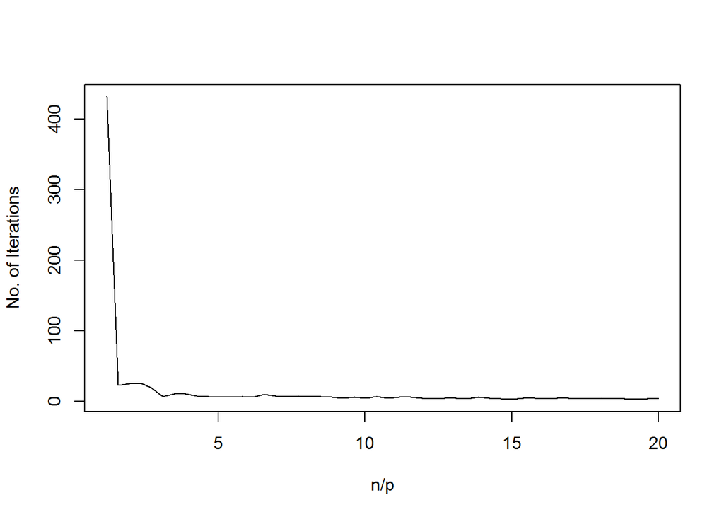

```r
plot(n_p, n.iter.vec, xlab = "n/p", ylab = "No. of Iterations", type = "l")
```

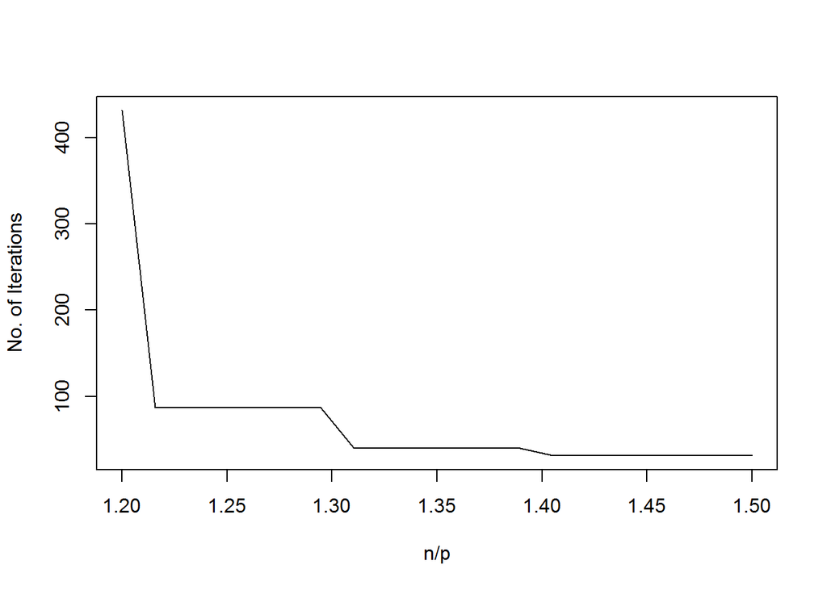

```r
p = 10
n_p = seq(from = 1.2, to = 1.5, length = 20)
n.vec = ceiling(p*n_p)
n.iter.vec = rep(NA, length = length(n.vec))

for (i in 1:length(n.vec)) {
  n.iter.vec[i] = backfit.n.iter(n = n.vec[i], p, tol = 1e-3, max.n.iter = 500)
}
plot(n_p, n.iter.vec, xlab = "n/p", ylab = "No. of Iterations", type = "l")
```